# Stage 1 Diagnostics

Convergence, tuning, coefficient plausibility, conditional-forecast sanity, and fit – for all 11 country satellite models

## 1. Convergence

`R/diagnostics.R` provides `diagnostics_grid()` / `save_stage1_plots()`, wrapping koma’s `trace_plot()`, `running_mean_plot()`, and `acf_plot()` across every stochastic equation in every country. The full set – 3 plot kinds x 6-7 equations x 11 countries – is saved under `reports/stage1/<iso2>/`. Below is one representative country (Germany); the remaining ten follow an identical pattern and are linked at the end of this section.

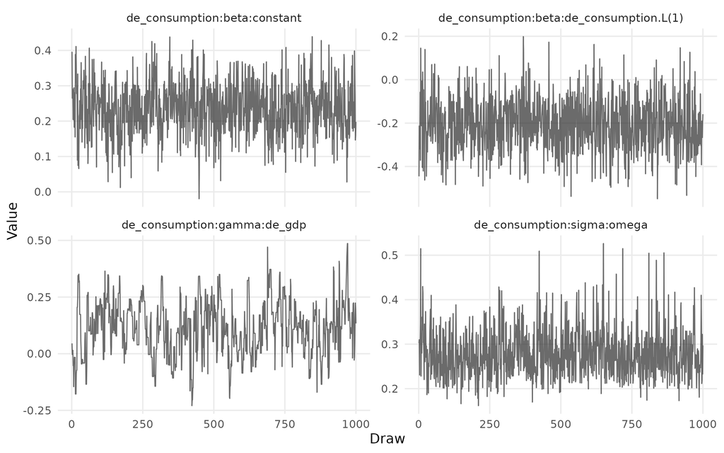

Trace: `de_consumption`

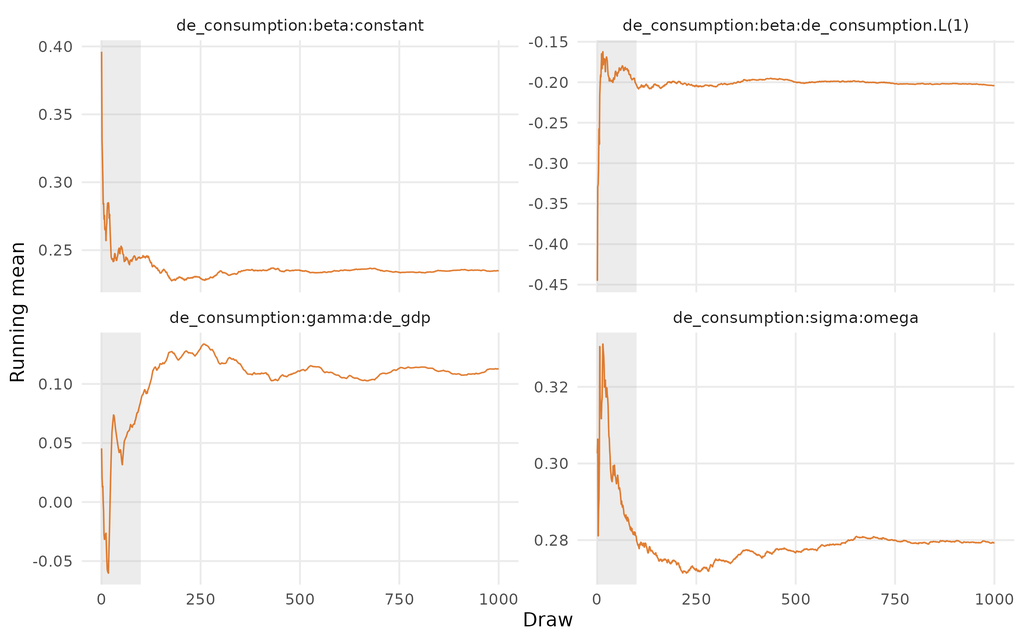

Running mean: `de_consumption`

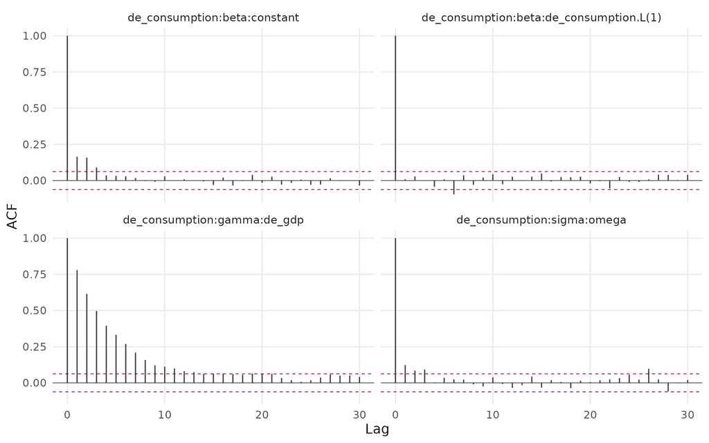

ACF: `de_consumption`

**Automated stability flag.** `check_running_mean_stability()` recovers each coefficient’s raw per-draw values from koma’s cumulative `running_mean()`, restricts to the last third of the (post-grace) chain, and flags a coefficient if that tail’s drift (second half’s mean minus first half’s) exceeds 2 Monte Carlo standard errors. Applied to every coefficient in every equation in every country:

Running-mean stability: 0/291 coefficients flagged across all 11 countries.

| country | n_flagged | n_coefficients |
| --- | --- | --- |
| at | 0 | 26 |
| be | 0 | 26 |
| de | 0 | 26 |
| es | 0 | 26 |
| fr | 0 | 26 |
| gr | 0 | 26 |
| ie | 0 | 26 |
| it | 0 | 26 |
| nl | 0 | 26 |
| pt | 0 | 26 |
| us | 0 | 31 |

Zero coefficients, in any country, show an undecayed drift in the last third of the chain. Combined with the trace/ACF plots (visually well-mixed, no wandering or stuck chains – see the linked plots below), stage 1’s MCMC chains are judged converged everywhere.

Full plot sets: `reports/stage1/at/`, `.../be/`, `.../de/`, `.../es/`, `.../fr/`, `.../gr/`, `.../ie/`, `.../it/`, `.../nl/`, `.../pt/`, `.../us/`.

## 2. Acceptance rates and `tau` tuning

koma’s own target band is 20-60% (`koma:::get_default_acceptance_prob()`; see CLAUDE.md for why the code, not the vignette prose, is authoritative). At the baseline `tau = 1.1` every equation carries by default, several countries had one or two equations just over the 60% ceiling:

Equations outside the 20-60% band at baseline tau = 1.1.

| country | equation | acceptance_rate | flagged |
| --- | --- | --- | --- |
| at | at_consumption | 0.6095 | TRUE |
| at | at_investment | 0.6135 | TRUE |
| be | be_consumption | 0.6215 | TRUE |
| de | de_imports | 0.6040 | TRUE |
| de | de_long_rate | 0.6045 | TRUE |
| gr | gr_long_rate | 0.6065 | TRUE |
| es | es_investment | 0.6040 | TRUE |
| fr | fr_consumption | 0.6040 | TRUE |
| fr | fr_imports | 0.6005 | TRUE |
| it | it_investment | 0.6035 | TRUE |
| nl | nl_consumption | 0.6035 | TRUE |
| us | us_imports | 0.6120 | TRUE |

`tune_tau()` (`R/diagnostics.R`) re-estimates the country with every currently-flagged equation’s `tau` doubled (koma’s own documented “doubling tau halves the acceptance rate” rule of thumb), leaving in-band equations untouched, and repeats until every equation is in-band or `max_iter` is hit. This is a full re-estimate each round – a `tau` setting is not part of koma’s symbolic warm-start comparison, so nothing short of a full re-estimate would apply it. Run with `max_iter = 3`:

Before/after: every country converges to an in-band acceptance rate within 1-2 re-estimation rounds.

| country | iterations | converged | n_flagged_final | tuned_equations |
| --- | --- | --- | --- | --- |
| at | 1 | TRUE | 0 | at_consumption, at_investment |
| be | 2 | TRUE | 0 | be_consumption, be_imports |
| de | 1 | TRUE | 0 | de_imports, de_long_rate |
| gr | 2 | TRUE | 0 | gr_long_rate, gr_investment |
| es | 2 | TRUE | 0 | es_investment, es_consumption |
| fr | 1 | TRUE | 0 | fr_consumption, fr_imports |
| ie | 0 | TRUE | 0 | (none needed) |
| it | 2 | TRUE | 0 | it_investment, it_consumption |
| nl | 1 | TRUE | 0 | nl_consumption |
| pt | 0 | TRUE | 0 | (none needed) |
| us | 1 | TRUE | 0 | us_imports |

All 11 countries converge (every equation in-band) within at most 2 rounds; Ireland and Portugal needed no adjustment at all. `tau` never had to move past `2.2` (one doubling from `1.1`) except where two rounds were needed. This is a mild band violation, not a modelling problem: acceptance rates were 60.0-62.2%, a couple of points over the ceiling, not the kind of pathological (near-0% or near-100%) rate that would indicate a badly scaled proposal.

## 3. Coefficient plausibility

Three sign checks, applied to each country’s `coefficient_table()` posterior means (90% credible intervals from `ci_low`/`ci_high`) via `sign_checks()`:

- **`mpc_in_0_1`**: consumption’s loading on GDP should be a plausible marginal propensity to consume, in `(0, 1)`.
- **`import_elasticity_positive`**: imports’ loading on domestic demand should be positive.
- **`long_rate_loads_on_policy_rate`**: the long-rate equation’s loading on the policy rate (euro-area or US) should be positive.

Sign checks by country. Violations (ok = FALSE) are reported as-is, not corrected.

| country | check | equation | term | estimate | ok |
| --- | --- | --- | --- | --- | --- |
| at | mpc_in_0_1 | at_consumption | at_gdp | 0.370 | TRUE |
| at | import_elasticity_positive | at_imports | at_domestic_demand | 0.955 | TRUE |
| at | long_rate_loads_on_policy_rate | at_long_rate | ea_policy_rate | 0.071 | TRUE |
| be | mpc_in_0_1 | be_consumption | be_gdp | 0.364 | TRUE |
| be | import_elasticity_positive | be_imports | be_domestic_demand | 1.907 | TRUE |
| be | long_rate_loads_on_policy_rate | be_long_rate | ea_policy_rate | 0.048 | TRUE |
| de | mpc_in_0_1 | de_consumption | de_gdp | 0.113 | TRUE |
| de | import_elasticity_positive | de_imports | de_domestic_demand | 0.052 | TRUE |
| de | long_rate_loads_on_policy_rate | de_long_rate | ea_policy_rate | 0.051 | TRUE |
| gr | mpc_in_0_1 | gr_consumption | gr_gdp | 0.901 | TRUE |
| gr | import_elasticity_positive | gr_imports | gr_domestic_demand | 0.445 | TRUE |
| gr | long_rate_loads_on_policy_rate | gr_long_rate | ea_policy_rate | -0.129 | FALSE |
| es | mpc_in_0_1 | es_consumption | es_gdp | 1.201 | FALSE |
| es | import_elasticity_positive | es_imports | es_domestic_demand | 1.326 | TRUE |
| es | long_rate_loads_on_policy_rate | es_long_rate | ea_policy_rate | 0.003 | TRUE |
| fr | mpc_in_0_1 | fr_consumption | fr_gdp | 0.301 | TRUE |
| fr | import_elasticity_positive | fr_imports | fr_domestic_demand | 1.623 | TRUE |
| fr | long_rate_loads_on_policy_rate | fr_long_rate | ea_policy_rate | 0.045 | TRUE |
| ie | mpc_in_0_1 | ie_consumption | ie_gdp | -0.003 | FALSE |
| ie | import_elasticity_positive | ie_imports | ie_domestic_demand | 0.713 | TRUE |
| ie | long_rate_loads_on_policy_rate | ie_long_rate | ea_policy_rate | 0.003 | TRUE |
| it | mpc_in_0_1 | it_consumption | it_gdp | 0.326 | TRUE |
| it | import_elasticity_positive | it_imports | it_domestic_demand | 1.155 | TRUE |
| it | long_rate_loads_on_policy_rate | it_long_rate | ea_policy_rate | -0.001 | FALSE |
| nl | mpc_in_0_1 | nl_consumption | nl_gdp | 0.480 | TRUE |
| nl | import_elasticity_positive | nl_imports | nl_domestic_demand | 1.118 | TRUE |
| nl | long_rate_loads_on_policy_rate | nl_long_rate | ea_policy_rate | 0.070 | TRUE |
| pt | mpc_in_0_1 | pt_consumption | pt_gdp | 0.974 | TRUE |
| pt | import_elasticity_positive | pt_imports | pt_domestic_demand | 1.208 | TRUE |
| pt | long_rate_loads_on_policy_rate | pt_long_rate | ea_policy_rate | -0.091 | FALSE |
| us | mpc_in_0_1 | us_consumption | us_gdp | 0.328 | TRUE |
| us | import_elasticity_positive | us_imports | us_domestic_demand | 1.916 | TRUE |
| us | long_rate_loads_on_policy_rate | us_long_rate | us_policy_rate | -0.021 | FALSE |

6 of 33 checks fail, in 6 of 11 countries (GR, ES, IE, IT, PT, US). The failures cluster in one place: **`long_rate_loads_on_policy_rate`** fails in GR, IT, PT, and US, each with an estimate near zero or slightly negative (`-0.13` to `-0.001`) rather than a clear positive loading – the long-rate equation’s short estimation sample and lag structure leaves this coefficient weakly identified in several countries, not systematically wrong-signed by a large margin. Separately, ES’s marginal propensity to consume is `1.20` (above 1, an implausibly high sensitivity of consumption to GDP) and IE’s is effectively zero (`-0.003`) – consistent with Ireland’s well-documented national-accounts distortions from multinational activity (see `data_eamdqd.R`’s note on the 2015 GDP break) showing up again here. `import_elasticity_positive` never fails: every country’s imports load positively on domestic demand, as expected.

## 4. Conditional-forecast sanity

`conditional_forecast_check()` imposes two scenarios on each country’s existing stage-1 fit (`options = list(approximate = TRUE)`, a deterministic point forecast from posterior-mean coefficients, since `koma::forecast()` is otherwise stochastic between repeated calls on the same fit – see the function’s roxygen for the verified magnitudes):

- **oil**: oil price level +50% from the forecast start – expect `<iso2>_prices` to rise.
- **policy**: policy rate +100bp from the forecast start – expect `<iso2>_gdp` to fall.

Conditional-forecast sign check, by country and scenario (diff = scenario - baseline).

| country | scenario | target | horizon1_diff | horizon4_diff | expected_sign | all_horizons_sign_ok |
| --- | --- | --- | --- | --- | --- | --- |
| at | oil | at_prices | 0.4276 | 0.0102 | positive | TRUE |
| at | policy | at_gdp | 0.0000 | 0.0000 | negative | FALSE |
| be | oil | be_prices | 0.7547 | 0.0520 | positive | TRUE |
| be | policy | be_gdp | 0.0000 | 0.0000 | negative | FALSE |
| de | oil | de_prices | 0.5635 | 0.0031 | positive | TRUE |
| de | policy | de_gdp | 0.0000 | 0.0000 | negative | FALSE |
| es | oil | es_prices | 0.8686 | 0.0167 | positive | TRUE |
| es | policy | es_gdp | 0.0000 | 0.0000 | negative | FALSE |
| fr | oil | fr_prices | 0.5770 | 0.0209 | positive | TRUE |
| fr | policy | fr_gdp | 0.0000 | 0.0000 | negative | FALSE |
| gr | oil | gr_prices | 0.4865 | 0.0925 | positive | TRUE |
| gr | policy | gr_gdp | 0.0000 | 0.0000 | negative | FALSE |
| ie | oil | ie_prices | 0.5000 | 0.1803 | positive | TRUE |
| ie | policy | ie_gdp | 0.0000 | 0.0000 | negative | FALSE |
| it | oil | it_prices | 0.3723 | 0.0174 | positive | TRUE |
| it | policy | it_gdp | 0.0000 | 0.0000 | negative | FALSE |
| nl | oil | nl_prices | 0.2905 | 0.0285 | positive | TRUE |
| nl | policy | nl_gdp | 0.0000 | 0.0000 | negative | FALSE |
| pt | oil | pt_prices | 0.4169 | 0.0265 | positive | TRUE |
| pt | policy | pt_gdp | 0.0000 | 0.0000 | negative | FALSE |
| us | oil | us_prices | 1.0895 | 0.0097 | positive | TRUE |
| us | policy | us_gdp | 6.3731 | 0.6937 | negative | FALSE |

**Oil scenario: passes in all 11 countries.** A +50% oil-price level shock raises `<iso2>_prices` at every horizon, in every country, as expected – the largest effect is on impact (horizon 1) and decays through the horizon, consistent with the shock being a one-time level step feeding a `diff_log`-scale equation.

**Policy scenario: fails in all 11 countries, but not for the same reason in all of them.** In the stage-1 template (`stage1_spec()`), `<iso2>_long_rate` is the *only* equation the policy rate feeds into, and nothing downstream of `long_rate` exists at stage 1 – so for the ten euro-area countries, where `ea_policy_rate` is exogenous and the shock is imposed by rewriting its exogenous path (`shock_exogenous_level()`), GDP simply cannot move: the diff is exactly `0.0000` at every horizon. That is a structural property of the stage-1 specification (each country’s own small system, isolated from the rest), not a sign error to fix here; building the transmission channel (long rate -> investment/consumption, or a direct GDP channel) is exactly the kind of cross-equation interaction stage 2’s joint system is for.

The **US is different, and worse**: `us_policy_rate` is *endogenous* (its own Taylor-rule equation), so the shock is imposed via `koma::forecast(restrictions = )` instead of rewriting an exogenous series. That does move `us_gdp` – but in the **wrong direction**: `+6.37` at horizon 1, decaying to `+0.69` by horizon 4, i.e. GDP *rises* after a 100bp hike. There is still no structural channel from `us_policy_rate` to `us_gdp` in the stage-1 template, so this is not a real transmission effect; conditioning one endogenous variable’s path in `forecast(restrictions = )` perturbs the other equations’ draws through their *residual* correlation (the Gibbs sampler’s joint error structure), not through any regressor. That residual correlation is apparently positive here, producing a spurious, wrong-signed reaction rather than the euro-area countries’ clean “no effect”. This is worth flagging explicitly for stage 2: once `us_policy_rate` (or `ea_policy_rate`) has a real structural GDP channel, this artefact should disappear on its own; until then, nothing in this scenario’s US result should be read as GDP being genuinely more policy-sensitive one way or the other.

Both patterns are retained deliberately as a regression check across stages: the euro-area “no effect” and the US “wrong-signed residual leakage” should both resolve once stage 2 adds a genuine long-rate -> demand channel.

## 5. Fit

### In-sample RMSE

`rmse_in_sample()` reconstructs each equation’s fitted value from posterior-mean coefficients and koma’s own design matrices, on the **growth-rate** (`diff_log`, percent) scale koma estimates on:

In-sample RMSE per equation, quarterly percent growth-rate scale.

| country | equation | rmse | nobs |
| --- | --- | --- | --- |
| at | at_consumption | 0.679 | 78 |
| at | at_investment | 1.799 | 78 |
| at | at_exports | 2.181 | 78 |
| at | at_imports | 2.181 | 78 |
| at | at_prices | 0.255 | 78 |
| at | at_long_rate | 0.241 | 78 |
| be | be_consumption | 0.350 | 78 |
| be | be_investment | 2.424 | 78 |
| be | be_exports | 1.988 | 78 |
| be | be_imports | 1.800 | 78 |
| be | be_prices | 0.313 | 78 |
| be | be_long_rate | 0.270 | 78 |
| de | de_consumption | 0.461 | 78 |
| de | de_investment | 1.374 | 78 |
| de | de_exports | 2.241 | 78 |
| de | de_imports | 2.096 | 78 |
| de | de_prices | 0.268 | 78 |
| de | de_long_rate | 0.250 | 78 |
| gr | gr_consumption | 1.210 | 78 |
| gr | gr_investment | 6.957 | 78 |
| gr | gr_exports | 2.585 | 78 |
| gr | gr_imports | 4.465 | 78 |
| gr | gr_prices | 0.438 | 78 |
| gr | gr_long_rate | 1.545 | 78 |
| es | es_consumption | 0.665 | 78 |
| es | es_investment | 1.304 | 78 |
| es | es_exports | 1.998 | 78 |
| es | es_imports | 2.079 | 78 |
| es | es_prices | 0.431 | 78 |
| es | es_long_rate | 0.303 | 78 |
| fr | fr_consumption | 0.368 | 78 |
| fr | fr_investment | 0.685 | 78 |
| fr | fr_exports | 1.727 | 78 |
| fr | fr_imports | 1.390 | 78 |
| fr | fr_prices | 0.224 | 78 |
| fr | fr_long_rate | 0.246 | 78 |
| ie | ie_consumption | 1.144 | 78 |
| ie | ie_investment | 23.085 | 78 |
| ie | ie_exports | 4.350 | 78 |
| ie | ie_imports | 3.794 | 78 |
| ie | ie_prices | 0.359 | 78 |
| ie | ie_long_rate | 0.551 | 78 |
| it | it_consumption | 0.330 | 78 |
| it | it_investment | 1.333 | 78 |
| it | it_exports | 2.030 | 78 |
| it | it_imports | 1.808 | 78 |
| it | it_prices | 0.321 | 78 |
| it | it_long_rate | 0.345 | 78 |
| nl | nl_consumption | 0.474 | 78 |
| nl | nl_investment | 11.005 | 78 |
| nl | nl_exports | 1.860 | 78 |
| nl | nl_imports | 1.830 | 78 |
| nl | nl_prices | 0.379 | 78 |
| nl | nl_long_rate | 0.258 | 78 |
| pt | pt_consumption | 0.599 | 78 |
| pt | pt_investment | 1.975 | 78 |
| pt | pt_exports | 2.648 | 78 |
| pt | pt_imports | 2.053 | 78 |
| pt | pt_prices | 0.440 | 78 |
| pt | pt_long_rate | 0.694 | 78 |
| us | us_consumption | 0.326 | 78 |
| us | us_investment | 1.786 | 78 |
| us | us_exports | 1.874 | 78 |
| us | us_imports | 1.406 | 78 |
| us | us_prices | 0.298 | 78 |
| us | us_long_rate | 0.303 | 78 |
| us | us_policy_rate | 0.356 | 78 |

Most equations sit in a tight 0.2-2.6 percentage-point RMSE band. Two outliers stand out: **IE investment (23.1pp)** and **NL investment (11.0pp)** are far higher than every other equation, in any country. Ireland’s investment series is known to be distorted by multinational capital-relocation swings (again, the same national-accounts issue flagged in `data_eamdqd.R` and surfacing again in section 3’s MPC check); the Dutch figure, while smaller, points at the same kind of volatile, poorly-explained investment series rather than a specification error shared with the rest of the model.

### Pseudo-out-of-sample RMSE (2016Q1-2019Q4, expanding window)

`pseudo_oos_rmse()` wraps koma’s `model_evaluation()`: re-estimating with the sample expanded by one quarter at a time, forecasting `horizon = 4` quarters ahead, and reporting RMSE **on levels** (koma’s own default) – not comparable in magnitude to the in-sample table above (see that function’s roxygen for why `evaluate_on_levels = FALSE` was tried and rejected). Reported here by forecast horizon (1-4 quarters ahead), pooled across origins:

Pseudo-OOS RMSE, level-scale equations (consumption, investment, exports, imports).

| country | horizon | consumption | investment | exports | imports |
| --- | --- | --- | --- | --- | --- |
| at | 1 | 5.934000e+02 | 1.899000e+03 | 2728.6 | 1.051800e+03 |
| at | 2 | 6.180000e+02 | 2.185900e+03 | 2938.8 | 1.089900e+03 |
| at | 3 | 6.188000e+02 | 2.355700e+03 | 3170.3 | 1.068300e+03 |
| at | 4 | 6.453000e+02 | 2.552700e+03 | 3284.7 | 9.835000e+02 |
| be | 1 | 2.013000e+02 | 1.045200e+03 | 2546.6 | 4.705300e+03 |
| be | 2 | 1.916000e+02 | 1.144800e+03 | 2665.7 | 4.867200e+03 |
| be | 3 | 1.896000e+02 | 1.269800e+03 | 2660.4 | 4.883500e+03 |
| be | 4 | 2.564000e+02 | 1.289000e+03 | 2742.9 | 4.784800e+03 |
| de | 1 | 8.481500e+03 | 1.070170e+04 | 4414.5 | 6.947300e+03 |
| de | 2 | 9.443800e+03 | 1.224110e+04 | 4776.3 | 6.822900e+03 |
| de | 3 | 1.049770e+04 | 1.347980e+04 | 4998.5 | 7.366400e+03 |
| de | 4 | 1.139890e+04 | 1.542860e+04 | 5192.3 | 7.447600e+03 |
| es | 1 | 4.852900e+03 | 6.085200e+03 | 3260.7 | 6.115200e+03 |
| es | 2 | 3.381370e+04 | 1.144830e+04 | 3605.7 | 1.819000e+04 |
| es | 3 | 6.407874e+10 | 1.332486e+09 | 3580.3 | 1.438226e+10 |
| es | 4 | Inf | 1.723043e+132 | 3573.5 | Inf |
| fr | 1 | 1.866500e+03 | 6.173900e+03 | 6004.6 | 2.656500e+03 |
| fr | 2 | 2.023400e+03 | 7.229800e+03 | 6668.4 | 2.586100e+03 |
| fr | 3 | 2.172100e+03 | 8.406500e+03 | 6972.6 | 1.998800e+03 |
| fr | 4 | 2.321400e+03 | 9.533800e+03 | 7160.5 | 2.429600e+03 |
| gr | 1 | 5.005700e+03 | 2.035100e+03 | 1656.1 | 2.633100e+03 |
| gr | 2 | 2.710943e+18 | 4.493722e+50 | 1881.3 | 6.137433e+06 |
| gr | 3 | Inf | Inf | 2064.5 | Inf |
| gr | 4 | Inf | Inf | 2193.6 | Inf |
| ie | 1 | 8.244000e+02 | 1.037220e+04 | 3766.3 | 1.199870e+04 |
| ie | 2 | 9.017000e+02 | 1.355570e+04 | 3612.1 | 1.495790e+04 |
| ie | 3 | 9.681000e+02 | 1.350650e+04 | 3555.8 | 1.501620e+04 |
| ie | 4 | 1.054600e+03 | 2.015780e+04 | 3623.6 | 2.144010e+04 |
| it | 1 | 3.964900e+03 | 7.649400e+03 | 3707.2 | 7.510300e+03 |
| it | 2 | 9.463700e+03 | 1.462140e+04 | 3982.7 | 7.099200e+03 |
| it | 3 | 2.485192e+05 | 8.374168e+06 | 4204.9 | 6.896670e+04 |
| it | 4 | 2.782579e+13 | 2.778510e+47 | 4334.5 | 1.214294e+11 |
| nl | 1 | 3.099100e+03 | 2.127930e+04 | 5013.3 | 2.528560e+04 |
| nl | 2 | 1.643069e+15 | Inf | 5484.7 | 8.986306e+78 |
| nl | 3 | Inf | Inf | 5819.8 | Inf |
| nl | 4 | Inf | Inf | 6144.3 | Inf |
| pt | 1 | 2.228400e+03 | 2.097300e+03 | 1340.6 | 2.591800e+03 |
| pt | 2 | 3.817880e+04 | 3.130409e+05 | 1424.6 | 4.397720e+04 |
| pt | 3 | 2.577984e+33 | 4.907197e+96 | 1479.2 | 6.984545e+43 |
| pt | 4 | Inf | Inf | 1579.9 | Inf |
| us | 1 | 1.262000e+02 | 1.632000e+02 | 23.4 | 4.540000e+01 |
| us | 2 | 1.356000e+02 | 2.315000e+02 | 31.8 | 6.990000e+01 |
| us | 3 | 3.027000e+02 | 1.037500e+03 | 43.1 | 2.439000e+02 |
| us | 4 | 1.524000e+03 | 1.391900e+04 | 54.6 | 1.285200e+03 |

Pseudo-OOS RMSE, rate-scale equations (prices, long_rate, and US policy_rate).

| country | horizon | prices | long_rate | policy_rate |
| --- | --- | --- | --- | --- |
| at | 1 | 0.313 | 0.435 | NA |
| at | 2 | 0.341 | 0.484 | NA |
| at | 3 | 0.381 | 0.583 | NA |
| at | 4 | 0.398 | 0.614 | NA |
| be | 1 | 0.361 | 0.550 | NA |
| be | 2 | 0.421 | 0.619 | NA |
| be | 3 | 0.499 | 0.748 | NA |
| be | 4 | 0.641 | 0.799 | NA |
| de | 1 | 0.453 | 0.634 | NA |
| de | 2 | 0.476 | 0.714 | NA |
| de | 3 | 0.481 | 0.823 | NA |
| de | 4 | 0.476 | 0.862 | NA |
| es | 1 | 1.997 | 0.964 | NA |
| es | 2 | 2.207 | 1.109 | NA |
| es | 3 | 2.428 | 1.316 | NA |
| es | 4 | 2.644 | 1.434 | NA |
| fr | 1 | 1.058 | 0.896 | NA |
| fr | 2 | 1.123 | 0.992 | NA |
| fr | 3 | 1.174 | 1.128 | NA |
| fr | 4 | 1.221 | 1.187 | NA |
| gr | 1 | 2.480 | 8.724 | NA |
| gr | 2 | 2.800 | 9.637 | NA |
| gr | 3 | 3.124 | 10.670 | NA |
| gr | 4 | 3.452 | 11.586 | NA |
| ie | 1 | 1.922 | 0.513 | NA |
| ie | 2 | 2.133 | 0.605 | NA |
| ie | 3 | 2.362 | 0.756 | NA |
| ie | 4 | 2.576 | 0.821 | NA |
| it | 1 | 2.200 | 0.728 | NA |
| it | 2 | 2.411 | 0.757 | NA |
| it | 3 | 2.624 | 0.935 | NA |
| it | 4 | 2.867 | 1.049 | NA |
| nl | 1 | 1.227 | 0.746 | NA |
| nl | 2 | 1.254 | 0.824 | NA |
| nl | 3 | 1.273 | 0.948 | NA |
| nl | 4 | 1.286 | 0.994 | NA |
| pt | 1 | 1.646 | 4.158 | NA |
| pt | 2 | 1.879 | 4.612 | NA |
| pt | 3 | 2.154 | 5.112 | NA |
| pt | 4 | 2.426 | 5.500 | NA |
| us | 1 | 2.511 | 0.441 | 1.068 |
| us | 2 | 2.686 | 0.465 | 1.167 |
| us | 3 | 2.858 | 0.526 | 1.614 |
| us | 4 | 2.929 | 0.542 | 6.855 |

## 6. Per-country verdicts

Each paragraph below is generated from the tables in sections 1-5; the underlying data (not prose) is what to trust if a future re-run changes the numbers.

**AT (Austria).** Clean convergence, no stability flags. One equation (`at_investment`, alongside `at_consumption`) needed one round of `tau` tuning to reach the acceptance band; both converged easily. All three sign checks pass. Oil scenario correct; policy scenario shows the expected (stage-1-only) absence of a GDP channel. In-sample and pseudo-OOS RMSEs are unremarkable. **Usable as a stage-2 building block with no reservations.**

**BE (Belgium).** Clean convergence. Acceptance tuning took two rounds (`be_consumption`, then `be_imports`) but fully converged. All sign checks pass. Oil scenario correct. **Usable as a stage-2 building block with no reservations.**

**GR (Greece).** Clean convergence, two rounds of tuning (`gr_long_rate`, `gr_investment`), both converged. The `long_rate_loads_on_policy_rate` check **fails** (-0.13): plausible given Greece’s 2015 capital-controls episode and the one interpolated observation at `gr_long_rate` 2015Q3 (see CLAUDE.md) – the long-rate equation is estimated through a genuinely disrupted bond market. Other checks pass; oil scenario correct. **Usable as a stage-2 building block, but treat `gr_long_rate` as the weakest equation in this country’s system and do not lean on its policy-rate sensitivity for anything downstream.**

**ES (Spain).** Clean convergence, two rounds of tuning (`es_investment`, `es_consumption`), converged. The `mpc_in_0_1` check **fails**: consumption’s loading on GDP is `1.20`, above the plausible range, implying consumption over-reacts to GDP growth one-for-one plus some. Import elasticity and long-rate checks pass; oil scenario correct. **Usable as a stage-2 building block, but the consumption equation’s GDP sensitivity should be revisited (priors, sample window, or an added regressor) before its multiplier effects are trusted quantitatively.**

**FR (France).** Clean convergence, one round of tuning (`fr_consumption`, `fr_imports`). All sign checks pass. Oil scenario correct; RMSEs unremarkable. **Usable as a stage-2 building block with no reservations.**

**IE (Ireland).** Clean convergence – and, notably, **no `tau` tuning was even needed**: every equation was already in-band at baseline. But this is the model with the most serious plausibility issues elsewhere: the `mpc_in_0_1` check **fails** (estimate effectively zero, `-0.003`, not a plausible consumption-GDP link), and `ie_investment`’s in-sample RMSE (**23.1pp**) is by far the largest of any equation in any country. Both point at the same well-documented cause – Ireland’s national accounts are distorted by multinational capital and IP relocation (the same issue behind the 2015 GDP break flagged in `data_eamdqd.R`). Oil scenario still correct (that channel is unaffected). **Usable as a stage-2 building block only with caution: the consumption and investment equations are not reliable in their current form, and Ireland’s results should be flagged as low-confidence in any stage-2/stage-3 output that depends on them.**

**IT (Italy).** Clean convergence, two rounds of tuning (`it_investment`, `it_consumption`), converged. `long_rate_loads_on_policy_rate` **fails**, though only marginally (-0.001, essentially zero rather than meaningfully negative) – a weak-identification result, not a strong-sign violation. Other checks pass; oil scenario correct. **Usable as a stage-2 building block; the long-rate equation’s policy sensitivity is negligible rather than wrong-signed and is a reasonable candidate to firm up once stage 2 shares information across countries.**

**NL (Netherlands).** Clean convergence, one round of tuning (`nl_consumption`). All sign checks pass. The one blemish is `nl_investment`’s in-sample RMSE (**11.0pp**), the second-largest of any equation after Ireland’s – smaller and less structurally explained, but still the country’s weakest equation. Oil scenario correct. **Usable as a stage-2 building block; keep an eye on the investment equation’s fit, but nothing here blocks using the model as specified.**

**PT (Portugal).** Clean convergence, and like Ireland, **no `tau` tuning was needed**. The `long_rate_loads_on_policy_rate` check **fails** (-0.09). Import elasticity and MPC pass; oil scenario correct. **Usable as a stage-2 building block; treat the long-rate equation the same way as Greece’s and Italy’s – weak, not wrong.**

**US (United States).** Clean convergence, one round of tuning (`us_imports`). The `long_rate_loads_on_policy_rate` check **fails** (-0.02, essentially zero) – notably, this is the one country where the policy rate is *endogenous* (its own Taylor-rule equation, `us_policy_rate`), yet the long-rate loading is still not positive, suggesting the weak identification seen in GR/IT/PT is a template-wide long-rate specification issue rather than something specific to the euro-area policy-rate sharing arrangement. `us_policy_rate`’s own acceptance rate (39.2%) and `us_long_rate`’s (40.4%) sit comfortably mid-band, well clear of any tuning need. Oil scenario correct. The policy scenario is the one genuinely concerning result in this report: because `us_policy_rate` is endogenous, the +100bp shock is imposed via `forecast(restrictions = )`, and `us_gdp` moves the *wrong way* (up, not down) – a spurious effect leaking in through the Gibbs sampler’s residual correlation across equations rather than any real regressor link (see section 4). **Usable as a stage-2 building block for its own equations, but do not use this country’s conditional-forecast machinery for anything policy-rate-related until stage 2 gives `us_policy_rate` a genuine GDP channel; until then, treat any US policy-scenario output as an artefact, not a result.**

### Cross-country pattern

The `long_rate_loads_on_policy_rate` check is the recurring failure (GR, IT, PT, US – four of six total sign-check failures), and it fails in both euro-area and US variants of the identical equation template. That points at the equation itself (`<iso2>_long_rate ~ <iso2>_prices + policy_rate + <iso2>_long_rate.L(1)`) being under-specified for a positive policy-rate loading generally, not a country-specific data problem – worth revisiting the template (an additional lag, a term capturing sovereign risk/spread dynamics) before stage 2, since every country’s long-rate equation inherits the same structure.

Every country converges cleanly (acceptance and stability) and every country’s oil-price transmission is correctly signed. The policy-rate-to- GDP scenario failing everywhere is expected and not a defect – it is the gap stage 2 exists to close. With that caveat, **all 11 stage-1 country models are usable as stage-2 building blocks**; ES and IE need the most attention (consumption equation) before their multiplier implications should be trusted, and GR/IT/PT/US share a long-rate equation that is weak but not wrong-signed in a way that would corrupt a joint estimation.

## Eight-quarter forecast

8 quarters from **2023Q1** to **2024Q4**, 1000 posterior draws. The whole window is already observed, so this is an out-of-sample check rather than a projection.

Every fan below is the **filtered** predictive interval: koma constrains no draw to be stationary, so a draw whose quarterly growth exceeds 100% in absolute value is dropped before the quantiles are taken, exactly as `score_forecast()` does when it scores a backtest. The solid band is the 25th-75th percentile of what survives, the faint band the 10th-90th, the dark line their median, and the grey line the realised path where one exists. Across the variables shown, **0.4%** of draws are discarded as explosive at horizon 1, rising to **2.8%** at horizon 8 (worst: `gr_gdp` at 21.0%). A variable whose discarded share climbs steeply is one whose fan **understates** the model’s true uncertainty, so read the tail of a wide fan as an ordering rather than a number.

**The level paths are anchored on conditionally-filled values, not observed ones.** koma takes the anchor from the end of the fit’s own `ts_data`, and this stage fills 2022Q4 before forecasting. The worst discrepancy is `ie_investment`, anchored at 5.918e+04 against an observed 2.311e+04 – **156.1% out** – and the median across all variables is 4.2%. A level gap at horizon 1 is therefore inherited from the fill, not produced by the forecast. **Read the rate chart, which is unaffected.**

### GDP

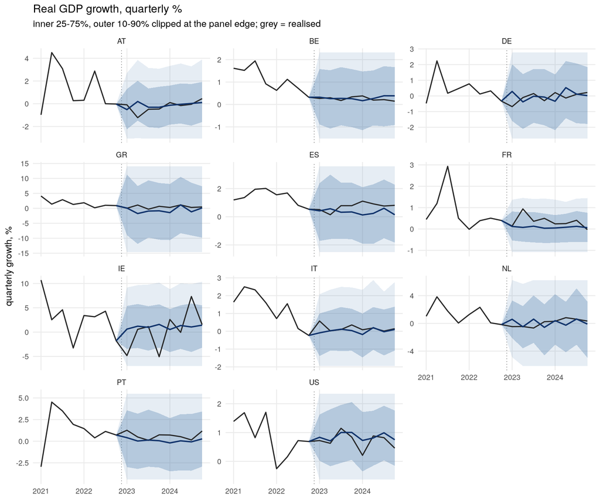

Median GDP growth forecast by quarter, percent.

| quarter | AT | BE | DE | GR | ES | FR | IE | IT | NL | PT | US |
| --- | --- | --- | --- | --- | --- | --- | --- | --- | --- | --- | --- |
| 2023Q1 | -0.52 | 0.32 | 0.29 | 0.09 | 0.42 | 0.12 | 0.62 | -0.09 | 0.59 | 0.40 | 0.83 |
| 2023Q2 | 0.20 | 0.26 | -0.38 | -1.75 | 0.57 | 0.07 | 1.22 | 0.03 | -0.48 | 0.02 | 0.71 |
| 2023Q3 | -0.31 | 0.27 | -0.02 | -0.91 | 0.32 | 0.13 | 0.99 | 0.11 | 0.62 | 0.13 | 1.00 |
| 2023Q4 | -0.31 | 0.26 | -0.07 | -0.83 | 0.34 | 0.04 | 1.59 | 0.04 | -0.57 | 0.05 | 1.00 |
| 2024Q1 | -0.13 | 0.17 | -0.34 | -1.44 | 0.13 | 0.05 | 0.54 | -0.18 | 0.40 | -0.20 | 0.73 |
| 2024Q2 | -0.05 | 0.27 | 0.53 | 1.15 | 0.24 | 0.08 | 1.36 | 0.20 | -0.26 | 0.04 | 0.81 |
| 2024Q3 | 0.03 | 0.39 | 0.11 | -1.17 | 0.60 | 0.12 | 1.06 | -0.03 | 0.63 | -0.08 | 0.99 |
| 2024Q4 | 0.11 | 0.39 | 0.02 | 0.15 | 0.14 | 0.06 | 1.43 | 0.10 | -0.10 | 0.27 | 0.75 |

### Prices

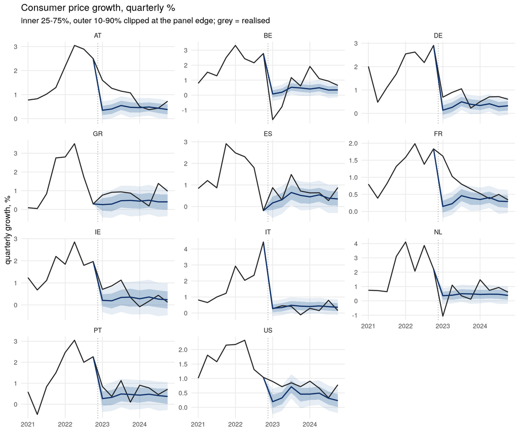

Median price growth forecast by quarter, percent.

| quarter | AT | BE | DE | GR | ES | FR | IE | IT | NL | PT | US |
| --- | --- | --- | --- | --- | --- | --- | --- | --- | --- | --- | --- |
| 2023Q1 | 0.35 | 0.08 | 0.14 | 0.26 | 0.17 | 0.15 | 0.21 | 0.29 | 0.36 | 0.27 | 0.20 |
| 2023Q2 | 0.40 | 0.19 | 0.26 | 0.29 | 0.32 | 0.23 | 0.19 | 0.34 | 0.39 | 0.33 | 0.33 |
| 2023Q3 | 0.55 | 0.52 | 0.50 | 0.47 | 0.65 | 0.46 | 0.34 | 0.48 | 0.50 | 0.49 | 0.71 |
| 2023Q4 | 0.47 | 0.48 | 0.39 | 0.48 | 0.52 | 0.39 | 0.35 | 0.43 | 0.48 | 0.47 | 0.46 |
| 2024Q1 | 0.46 | 0.41 | 0.34 | 0.44 | 0.45 | 0.35 | 0.28 | 0.41 | 0.45 | 0.43 | 0.46 |
| 2024Q2 | 0.48 | 0.49 | 0.41 | 0.49 | 0.54 | 0.41 | 0.36 | 0.44 | 0.47 | 0.48 | 0.49 |
| 2024Q3 | 0.44 | 0.34 | 0.29 | 0.40 | 0.39 | 0.30 | 0.26 | 0.39 | 0.46 | 0.41 | 0.32 |
| 2024Q4 | 0.38 | 0.35 | 0.33 | 0.40 | 0.35 | 0.29 | 0.24 | 0.36 | 0.38 | 0.37 | 0.23 |

### Forecast against outturn

The whole horizon is observed, so the forecast can simply be compared with what happened. This is not a formal backtest – `reports/evaluation.qmd` is, across many origins – but it is the cheapest honest look at whether the stage is producing sensible paths.

GDP growth: median forecast (fc) against outturn (act), percent.

| quarter | AT fc | AT act | BE fc | BE act | DE fc | DE act | GR fc | GR act | ES fc | ES act | FR fc | FR act | IE fc | IE act | IT fc | IT act | NL fc | NL act | PT fc | PT act | US fc | US act |
| --- | --- | --- | --- | --- | --- | --- | --- | --- | --- | --- | --- | --- | --- | --- | --- | --- | --- | --- | --- | --- | --- | --- |
| 2023Q1 | -0.52 | -0.09 | 0.32 | 0.27 | 0.29 | -0.68 | 0.09 | 0.03 | 0.42 | 0.51 | 0.12 | 0.14 | 0.62 | -4.83 | -0.09 | 0.58 | 0.59 | -0.46 | 0.40 | 1.26 | 0.83 | 0.72 |
| 2023Q2 | 0.20 | -1.23 | 0.26 | 0.30 | -0.38 | -0.10 | -1.75 | 1.10 | 0.57 | 0.14 | 0.07 | 0.94 | 1.22 | 0.57 | 0.03 | 0.02 | -0.48 | -0.45 | 0.02 | 0.48 | 0.71 | 0.63 |
| 2023Q3 | -0.31 | -0.49 | 0.27 | 0.18 | -0.02 | 0.15 | -0.91 | -0.29 | 0.32 | 0.79 | 0.13 | 0.36 | 0.99 | 1.14 | 0.11 | 0.10 | 0.62 | -0.67 | 0.13 | 0.10 | 1.00 | 1.15 |
| 2023Q4 | -0.31 | -0.47 | 0.26 | 0.34 | -0.07 | -0.31 | -0.83 | 0.67 | 0.34 | 0.79 | 0.04 | 0.50 | 1.59 | -5.06 | 0.04 | 0.36 | -0.57 | 0.25 | 0.05 | 0.73 | 1.00 | 0.84 |
| 2024Q1 | -0.13 | 0.10 | 0.17 | 0.38 | -0.34 | 0.21 | -1.44 | 0.29 | 0.13 | 1.11 | 0.05 | 0.24 | 0.54 | 2.60 | -0.18 | 0.08 | 0.40 | 0.31 | -0.20 | 0.71 | 0.73 | 0.21 |
| 2024Q2 | -0.05 | -0.16 | 0.27 | 0.19 | 0.53 | -0.13 | 1.15 | 1.13 | 0.24 | 0.91 | 0.08 | 0.25 | 1.36 | -0.05 | 0.20 | 0.19 | -0.26 | 0.83 | 0.04 | 0.52 | 0.81 | 0.88 |
| 2024Q3 | 0.03 | -0.05 | 0.39 | 0.22 | 0.11 | 0.10 | -1.17 | 0.29 | 0.60 | 0.76 | 0.12 | 0.41 | 1.06 | 7.32 | -0.03 | 0.01 | 0.63 | 0.60 | -0.08 | 0.14 | 0.99 | 0.82 |
| 2024Q4 | 0.11 | 0.45 | 0.39 | 0.15 | 0.02 | 0.22 | 0.15 | 0.47 | 0.14 | 0.81 | 0.06 | -0.03 | 1.43 | 1.54 | 0.10 | 0.14 | -0.10 | 0.34 | 0.27 | 1.17 | 0.75 | 0.46 |

### What was discarded, and what the exogenous path assumes

Share of posterior draws discarded as explosive, by variable.

| variable | explosive share, h1 | h8 | max |
| --- | --- | --- | --- |
| gr_gdp | 0.063 | 0.210 | 0.210 |
| nl_gdp | 0.002 | 0.173 | 0.173 |
| es_gdp | 0.011 | 0.122 | 0.122 |
| pt_gdp | 0.008 | 0.067 | 0.067 |
| at_gdp | 0.000 | 0.011 | 0.011 |
| de_gdp | 0.001 | 0.010 | 0.010 |
| it_gdp | 0.000 | 0.008 | 0.008 |
| be_gdp | 0.002 | 0.007 | 0.007 |
| us_gdp | 0.000 | 0.007 | 0.007 |
| ie_gdp | 0.000 | 0.001 | 0.001 |
| fr_gdp | 0.000 | 0.000 | 0.000 |
| at_prices | 0.000 | 0.000 | 0.000 |
| be_prices | 0.000 | 0.000 | 0.000 |
| de_prices | 0.000 | 0.000 | 0.000 |
| gr_prices | 0.000 | 0.000 | 0.000 |
| es_prices | 0.000 | 0.000 | 0.000 |
| fr_prices | 0.000 | 0.000 | 0.000 |
| ie_prices | 0.000 | 0.000 | 0.000 |
| it_prices | 0.000 | 0.000 | 0.000 |
| nl_prices | 0.000 | 0.000 | 0.000 |
| pt_prices | 0.000 | 0.000 | 0.000 |
| us_prices | 0.000 | 0.000 | 0.000 |

The untruncated predictive band at horizon 8 – quarterly growth, percent. This is what the charts clip.

| variable | median | inner_low | inner_high | outer_low | outer_high | outer_width |
| --- | --- | --- | --- | --- | --- | --- |
| at_gdp | 0.1 | -1.6 | 1.9 | -3.4 | 3.9 | 7.3 |
| be_gdp | 0.4 | -0.9 | 1.7 | -2.1 | 2.9 | 5.0 |
| de_gdp | 0.0 | -1.8 | 1.8 | -3.6 | 3.7 | 7.3 |
| gr_gdp | 0.2 | -9.8 | 7.4 | -23.7 | 21.4 | 45.1 |
| es_gdp | 0.1 | -1.8 | 2.3 | -4.6 | 4.4 | 9.0 |
| fr_gdp | 0.1 | -0.6 | 0.8 | -1.3 | 1.4 | 2.7 |
| ie_gdp | 1.4 | -3.2 | 5.5 | -7.6 | 10.4 | 18.0 |
| it_gdp | 0.1 | -1.1 | 1.4 | -2.4 | 2.8 | 5.2 |
| nl_gdp | -0.1 | -4.9 | 3.2 | -16.0 | 10.1 | 26.1 |
| pt_gdp | 0.3 | -2.9 | 3.4 | -7.3 | 8.5 | 15.8 |
| us_gdp | 0.7 | -0.2 | 1.8 | -1.3 | 3.1 | 4.4 |
| at_prices | 0.4 | 0.2 | 0.6 | 0.0 | 0.8 | 0.8 |
| be_prices | 0.3 | 0.1 | 0.6 | -0.1 | 0.8 | 0.9 |
| de_prices | 0.3 | 0.1 | 0.5 | -0.1 | 0.7 | 0.8 |
| gr_prices | 0.4 | 0.0 | 0.8 | -0.4 | 1.2 | 1.6 |
| es_prices | 0.4 | 0.0 | 0.7 | -0.3 | 1.0 | 1.3 |
| fr_prices | 0.3 | 0.1 | 0.5 | 0.0 | 0.6 | 0.6 |
| ie_prices | 0.2 | -0.2 | 0.6 | -0.5 | 1.0 | 1.5 |
| it_prices | 0.4 | 0.1 | 0.6 | -0.1 | 0.8 | 0.9 |
| nl_prices | 0.4 | 0.1 | 0.7 | -0.2 | 1.0 | 1.2 |
| pt_prices | 0.4 | 0.0 | 0.8 | -0.3 | 1.1 | 1.4 |
| us_prices | 0.2 | 0.0 | 0.5 | -0.2 | 0.7 | 0.9 |

A forecast this long needs the **exogenous** series to reach the end of the horizon, and they do not: every one of them stops at the fit’s own native forecast end. `extend_forecast_horizon()` carries each one forward on its trailing four-quarter average growth – a momentum continuation, not a view on oil markets or world trade – and koma would otherwise have silently returned a shorter horizon than the one requested.

How each exogenous series was carried past the fit’s native forecast end.

| variable | method | periods_added |
| --- | --- | --- |
| row_gdp | trailing-4Q avg growth (0.72%/q) | 4 |
| eur_usd | trailing-4Q avg growth (2.67%/q) | 4 |
| oil_price | trailing-4Q avg growth (1.41%/q) | 4 |
| ea_policy_rate | flat at trailing-4Q average (2.21) | 4 |
| at_government | trailing-4Q avg growth (0.67%/q) | 4 |